# **Chapter 6: Analysis of longitudinal data**

```r
date()
```

```
## [1] "Tue Dec 13 04:20:50 2022"
```

## **Analysis exercises**

### **Analyzing RATS data**

> The prepared RATS data by [Martin J. Crowder and David J. Hand](https://doi.org/10.1201/9781315137421) measures the body weight of rats over a 64-day period (once a week). It consists of five variables and 176 observations each. The variables are ID (n = 16), Group (n = 3), WD (original **w**eight measuring **d**ay I left in the data just in case), Weight_g (g for grams), and Time (weight measuring day).

```r
# Import prepared RATS data.
rats <- read.csv("Data/rats.csv")

# Check data properties.
str(rats)
```

```
## 'data.frame':    176 obs. of  5 variables:
##  $ ID      : int  1 2 3 4 5 6 7 8 9 10 ...
##  $ Group   : int  1 1 1 1 1 1 1 1 2 2 ...
##  $ WD      : chr  "WD1" "WD1" "WD1" "WD1" ...
##  $ Weight_g: int  240 225 245 260 255 260 275 245 410 405 ...
##  $ Time    : int  1 1 1 1 1 1 1 1 1 1 ...
```

> ID and Group variables should be treated as names/lables (factors) instead of values (integers), therefore these will be converted. Curiously, the summary table shows that there are twice the amount of observations for Group 1 (n = 88) compared to other two groups (n = 44).

```r
# Convert ID and Group from integers (numbers) to factors.
library(tidyverse)

rats <-
  rats %>% mutate(ID = as.factor(ID), Group = as.factor(Group))

# Check summary.
summary(rats)
```

```
##        ID      Group       WD               Weight_g          Time
##  1      : 11   1:88   Length:176         Min.   :225.0   Min.   : 1.00
##  2      : 11   2:44   Class :character   1st Qu.:267.0   1st Qu.:15.00
##  3      : 11   3:44   Mode  :character   Median :344.5   Median :36.00
##  4      : 11                             Mean   :384.5   Mean   :33.55
##  5      : 11                             3rd Qu.:511.2   3rd Qu.:50.00
##  6      : 11                             Max.   :628.0   Max.   :64.00
##  (Other):110
```

> Checking the distribution of the weights via a density plot and a Q-Q plot reveals that it is not normally distributed and there are two distinct groups of rats (those below ca. 300 grams and others above ca. 400 grams).

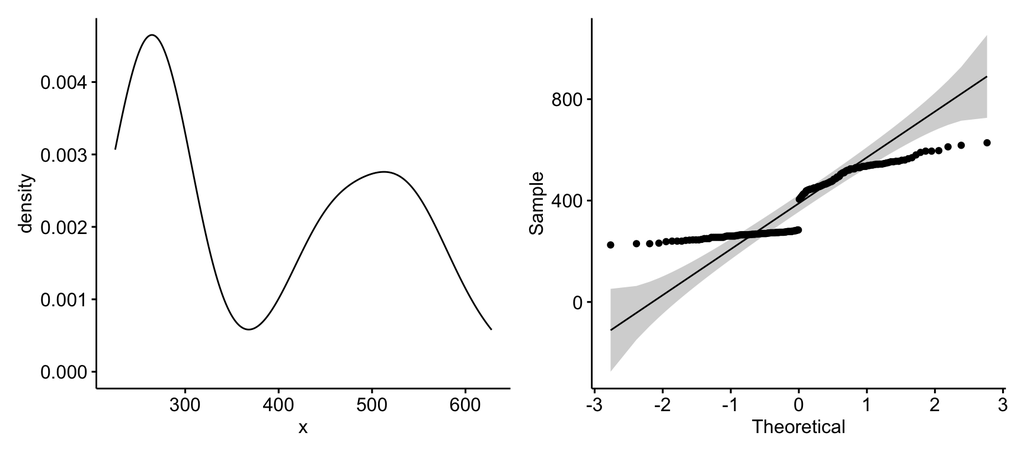

```r
library(ggpubr)
library(patchwork)

density_plot <- ggdensity(rats$Weight_g)
qqplot <- ggqqplot(rats$Weight_g)

density_plot + qqplot
```

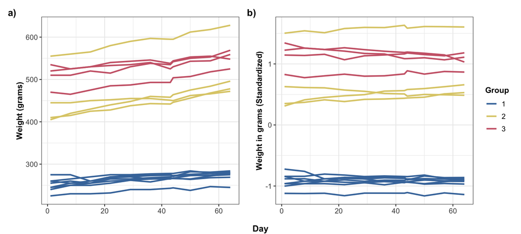

```r
library(ggthemes)
library(gridExtra)

# Plot data as is.
line_plot1 <- ggplot(rats, aes(
  x = Time,
  y = Weight_g,
  group = ID,
  color = Group
)) +
  geom_line(linewidth = 1) +
  labs(y = "Weight (grams)") +
  scale_color_manual(values = ptol_pal()(length(unique(rats$Group)))) +
  theme_bw() +
  theme(
    axis.title = element_text(face = "bold"),
    axis.text = element_text(size = 10),
    axis.title.x = element_blank(),
    legend.title = element_text(face = "bold"),
    legend.text = element_text(size = 10)
  )

# Standardize data and plot again.
rats_scaled <- rats %>% group_by(Time) %>%
  mutate(Weight_scaled = scale(Weight_g)) %>%
  ungroup()

line_plot2 <- ggplot(rats_scaled,
                     aes(
                       x = Time,
                       y = Weight_scaled,
                       group = ID,
                       color = Group
                     )) +
  geom_line(linewidth = 1) +
  labs(y = "Weight in grams (Standardized)") +
  scale_color_manual(values = ptol_pal()(length(unique(rats$Group)))) +
  theme_bw() +
  theme(
    axis.title = element_text(face = "bold"),
    axis.text = element_text(size = 10),
    axis.title.x = element_blank(),
    legend.title = element_text(face = "bold"),
    legend.text = element_text(size = 10)
  )

# Join plots.
joined_plot <- line_plot1 + line_plot2 +
  plot_layout(guides = "collect") +
  plot_annotation(tag_levels = "a", tag_suffix = ")") &
  theme(
    legend.text = element_text(color = "black", size = 10),
    plot.tag = element_text(color = "black", face = "bold")
  )

grid.arrange(patchworkGrob(joined_plot),
             bottom = text_grob("Day", face = "bold"))
```

> The data will be next summarized with a summary plot of means and standard errors. The relationship between the groups seems to stay the same even with Group 2 and its outlier (panel a). However, this results in a wider deviation and higher mean. Removing the outlier reduces the variation and lowers the mean weight (panel b).

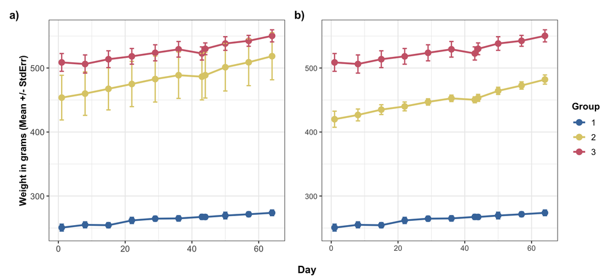

```r
# Calculate mean weights and standard errors.
rats_mean <- rats %>%
  group_by(Group, Time) %>%
  summarise(Weight_mean = mean(Weight_g),
            Weight_se = sd(Weight_g) / sqrt(length((Weight_g)))) %>%
  ungroup()

# Plot mean of raw data.
summary_plot1 <- ggplot(rats_mean,
                        aes(x = Time,
                            y = Weight_mean,
                            color = Group)) +
  geom_line(linewidth = 1) +
  geom_point(size = 3) +
  geom_errorbar(
    aes(ymin = Weight_mean - Weight_se,
        ymax = Weight_mean + Weight_se),
    width = 1.3,
    linewidth = 0.7
  ) +
  scale_color_manual(values = ptol_pal()(length(unique(rats_mean$Group)))) +
  labs(y = "Weight in grams (Mean +/- StdErr)") +
  theme_bw() +
  theme(
    axis.title = element_text(face = "bold"),
    axis.text = element_text(size = 10),
    axis.title.x = element_blank(),
    legend.title = element_text(face = "bold"),
    legend.text = element_text(size = 10),
  )

# Remove outlier i.e., ID 12, and recalculate values.
rats_mean_filtered <- rats %>% filter(ID != "12") %>%
  group_by(Group, Time) %>%
  summarise(Weight_mean = mean(Weight_g),
            Weight_se = sd(Weight_g) / sqrt(length((Weight_g)))) %>%
  ungroup()

# Plot filtered data.
summary_plot2 <- ggplot(rats_mean_filtered,
       aes(x = Time,
           y = Weight_mean,
           color = Group)) +
  geom_line(linewidth = 1) +
  geom_point(size = 3) +
  geom_errorbar(
    aes(ymin = Weight_mean - Weight_se,
        ymax = Weight_mean + Weight_se),
    width = 1.3,
    linewidth = 0.7
  ) +
  scale_color_manual(values = ptol_pal()(length(unique(rats_mean$Group)))) +
  theme_bw() +
  theme(
    axis.title = element_blank(),
    legend.title = element_text(face = "bold"),
    legend.text = element_text(size = 10),
  )

summary_plots <- summary_plot1 + summary_plot2 +
  plot_layout(guides = "collect") +
  plot_annotation(tag_levels = "a", tag_suffix = ")") &
  theme(
    legend.text = element_text(color = "black", size = 10),
    plot.tag = element_text(color = "black", face = "bold")
  )

grid.arrange(patchworkGrob(summary_plots),
             bottom = text_grob("Day", face = "bold"))
```

> Plotting the data with a box plot conversely shows that there are no outliers. Before plotting the data, I removed baseline measurements (day 1) in preparation for t-test and ANOVA later. While I could assume based on this that it is okay to run these tests on this data as is, I’ll use the data without the outlier rat (ID 12).

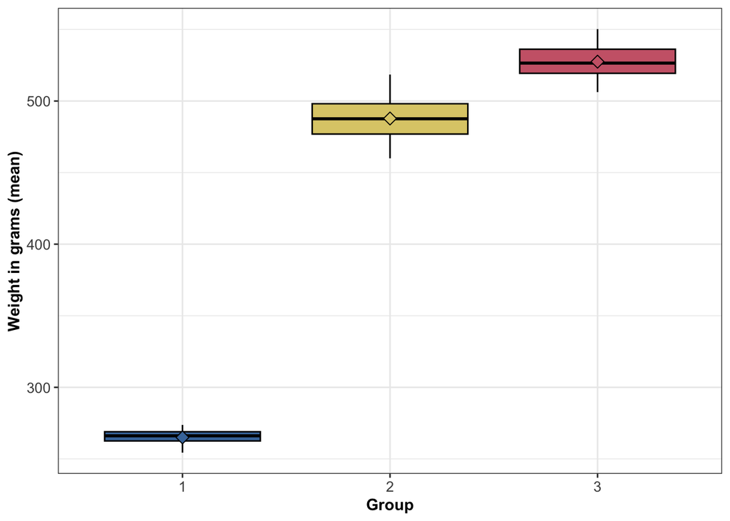

```r
# Filter out baseline weight i.e., weight on day 1.
new_rats_mean <- rats_mean %>% filter(Time > 1)

# Make box plot.
ggplot(new_rats_mean,
       aes(x = Group,
           y = Weight_mean, fill = Group)) +
  geom_boxplot(color = "black") +
  stat_summary(
    fun = "mean",
    geom = "point",
    shape = 23,
    size = 3
  ) +
  scale_fill_manual(values = ptol_pal()(length(unique(rats_mean$Group))), guide = "none") +
  labs(x = "Group", y = "Weight in grams (mean)") +
  theme_bw() +
  theme(
    axis.title = element_text(face = "bold"),
    legend.title = element_text(face = "bold"),
    legend.text = element_text(size = 10),
    axis.text = element_text(size = 10)
  )
```

> The t-test, which was run to see whether there is a statistical difference in mean weights among the rat groups, resulted in the following table. Looking at the p-values, it is safe to assume that we can reject the null hypothesis (there is **no** statistical difference in mean weights among the rat groups). The plot already show as much but it is nice to have a quantitative/statistical measure confirming this.

```r
library(rstatix)
library(knitr)

# Remove baseline (day 1) measurements.
new_rats_mean_filtered <- rats_mean_filtered %>% filter(Time > 1)

# Run t-test and output results to a table.
kable(new_rats_mean_filtered %>% t_test(Weight_mean ~ Group))
```

| .y. | group1 | group2 | n1 | n2 | statistic | df | p | p.adj | p.adj.signif |
| --- | --- | --- | --- | --- | --- | --- | --- | --- | --- |
| Weight_mean | 1 | 2 | 10 | 10 | -32.70072 | 11.54387 | 0 | 0 | **** |
| Weight_mean | 1 | 3 | 10 | 10 | -55.64033 | 12.90932 | 0 | 0 | **** |
| Weight_mean | 2 | 3 | 10 | 10 | -10.97700 | 17.12515 | 0 | 0 | **** |

> To run t-test and ANOVA, I created a new dataframe which has mean weights per ID. Based on previous plots and analyses, I’ll filter out baseline measurements and ID 12 as an outlier. The fitted linear model of rats shows statistically positive correlation among inputted variables, and looks really good (maybe too good): the residuals seem to be equally distributed; p-values for coefficients are all statistically significant; and R<sup>2</sup> values are >99%, meaning that over 99% of the variance in mean weights can be explained by our model. This is a suspiciously accurate model with near-perfect predictive power. The ANOVA in turn shows that the mean weights differ from the baseline, and among the groups with statistical significance. The p-value of F-statistic shows that the fitted model is overall statistically significant.

```r
# Calculate mean weights per group.
rats_group_mean <-
  rats %>%
  filter(Time > 1, ID != "12") %>%
  group_by(Group, ID) %>%
  summarize(Weight_mean = mean(Weight_g))

# Create data frame of baseline weights.
rats_baseline <-
  rats %>%
  dplyr::filter(Time == "1", ID != "12") %>%
  group_by(Group, ID) %>%
  summarize(Weight_mean_day1 = mean(Weight_g))

# Join data frames.
new_rats <- inner_join(rats_group_mean, rats_baseline)

# Fit new data to a linear model and print summary.
rats_fit <-
  lm(Weight_mean ~ Weight_mean_day1 + Group, data = new_rats)

summary(rats_fit)
```

```
##
## Call:
## lm(formula = Weight_mean ~ Weight_mean_day1 + Group, data = new_rats)
##
## Residuals:
##      Min       1Q   Median       3Q      Max
## -11.2818  -5.4247  -0.0667   5.7389  13.7887
##
## Coefficients:
##                  Estimate Std. Error t value Pr(>|t|)
## (Intercept)      119.8515    31.5069   3.804 0.002923 **
## Weight_mean_day1   0.5792     0.1251   4.630 0.000728 ***
## Group2            89.2652    22.0021   4.057 0.001892 **
## Group3           112.9571    32.7344   3.451 0.005421 **
## ---
## Signif. codes:  0 '***' 0.001 '**' 0.01 '*' 0.05 '.' 0.1 ' ' 1
##
## Residual standard error: 8.749 on 11 degrees of freedom
## Multiple R-squared:  0.996,  Adjusted R-squared:  0.9949
## F-statistic: 911.4 on 3 and 11 DF,  p-value: 1.842e-13
```

```r
# Run ANOVA.
anova(rats_fit)
```

```
## Analysis of Variance Table
##
## Response: Weight_mean
##                  Df Sum Sq Mean Sq   F value    Pr(>F)
## Weight_mean_day1  1 207817  207817 2714.9357 1.601e-14 ***
## Group             2   1483     742    9.6878  0.003748 **
## Residuals        11    842      77
## ---
## Signif. codes:  0 '***' 0.001 '**' 0.01 '*' 0.05 '.' 0.1 ' ' 1
```

> Lastly, I wanted (as something extra) to see what the actual/quantitative difference was among mean weights of the rat groups compared to the baseline weight. The difference was quite small, yet based on the previous tests, statistically significant.

```r
kable(
  new_rats %>% group_by(Group) %>% summarize(
    Weight_mean = mean(Weight_mean),
    Weight_mean_day1 = mean(Weight_mean_day1),
    Difference = round(Weight_mean - Weight_mean_day1, 2),
    "Difference (%)" = round((1 - Weight_mean_day1 / Weight_mean) * 100, 2)
  )
)
```

| Group | Weight_mean | Weight_mean_day1 | Difference | Difference (%) |
| --- | --- | --- | --- | --- |
| 1 | 265.025 | 250.625 | 14.40 | 5.43 |
| 2 | 452.400 | 420.000 | 32.40 | 7.16 |
| 3 | 527.500 | 508.750 | 18.75 | 3.55 |

### **Analyzing BPRS data**

> The data from Davis (2002) contains the measurements of brief psychiatric rating scale (BPRS) for males (n = 40) over a period of eight weeks (1–8). There is also a baseline (week 0). The scale is between one and seven (from “not present” to “extremely severe”), and is used to diagnose schizophrenia. For this part of the exercises, I’ll use a prepared dataset, which has five variables (treatment, subject, week_og, bprs, and week) and 360 observations. The variable week_og is the original annotation for the measurement weeks. There’s nothing interesting in the data summary at a quick glance (for me at least).

```r
# Import prepared BPRS data.
bprs <-
  read.csv("Data/bprs.csv") %>%
  mutate(treatment = as.factor(treatment),
         subject = as.factor(subject),
         week = as.factor(week))

# Check data properties.
str(bprs)
```

```
## 'data.frame':    360 obs. of  5 variables:
##  $ treatment: Factor w/ 2 levels "1","2": 1 1 1 1 1 1 1 1 1 1 ...
##  $ subject  : Factor w/ 20 levels "1","2","3","4",..: 1 2 3 4 5 6 7 8 9 10 ...
##  $ week_og  : chr  "week0" "week0" "week0" "week0" ...
##  $ bprs     : int  42 58 54 55 72 48 71 30 41 57 ...
##  $ week     : Factor w/ 9 levels "0","1","2","3",..: 1 1 1 1 1 1 1 1 1 1 ...
```

```r
# Check summary of data.
summary(bprs)
```

```
##  treatment    subject      week_og               bprs            week
##  1:180     1      : 18   Length:360         Min.   :18.00   0      : 40
##  2:180     2      : 18   Class :character   1st Qu.:27.00   1      : 40
##            3      : 18   Mode  :character   Median :35.00   2      : 40
##            4      : 18                      Mean   :37.66   3      : 40
##            5      : 18                      3rd Qu.:43.00   4      : 40
##            6      : 18                      Max.   :95.00   5      : 40
##            (Other):252                                      (Other):120
```

> Plotting the data shows a rough downward trend in the BPRS values. It also shows a lot of variance among the subjects.

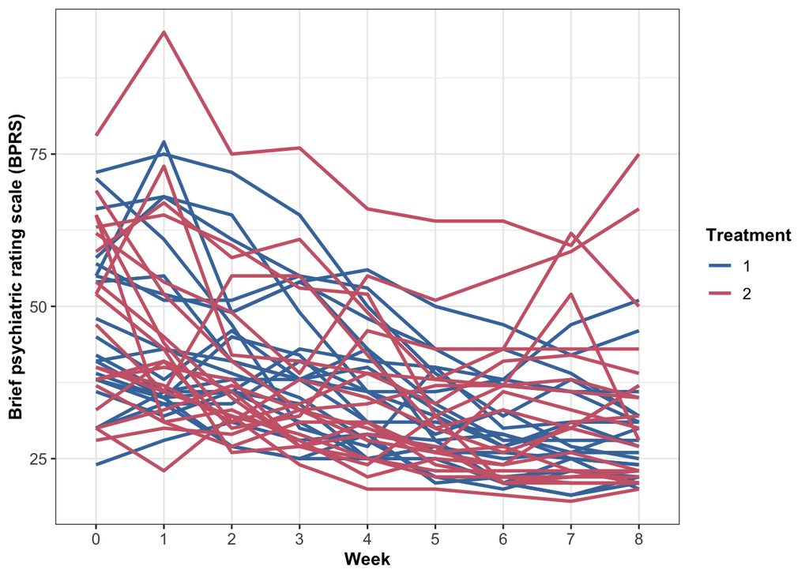

```r
ggplot(bprs, aes(
  x = week,
  y = bprs,
  group = interaction(subject, treatment),
  color = treatment
)) +
  geom_line(linewidth = 1) +
  labs(x = "Week", y = "Brief psychiatric rating scale (BPRS)", color = "Treatment") +
  scale_color_manual(values = ptol_pal()(length(unique(bprs$treatment)))) +
  theme_bw() +
  theme(
    axis.title = element_text(face = "bold"),
    legend.title = element_text(face = "bold"),
    legend.text = element_text(size = 10),
    axis.text = element_text(size = 10)
  )
```

> Fitting the variables into a linear model, it shows similar results. The estimates in the coefficients section are mostly negative supporting the negative association between BPRS and weeks, and these are mostly statistically significant with exception of week 1. Also treatment 2 is not statistically significant. The R<sup>2</sup> values show that ca. 20% of the variance in BPRS is explained by the inputted variables, meaning that the fitted model is not that great. The concluding F-statistics show a statistically significant overall p-value for the fitted model.

```r
bprs_reg <- lm(bprs ~ week + treatment, bprs)

summary(bprs_reg)
```

```
##
## Call:
## lm(formula = bprs ~ week + treatment, data = bprs)
##
## Residuals:
##     Min      1Q  Median      3Q     Max
## -23.714  -9.226  -2.989   6.786  48.389
##
## Coefficients:
##             Estimate Std. Error t value Pr(>|t|)
## (Intercept)  47.7139     2.0590  23.173  < 2e-16 ***
## week1        -1.6750     2.7624  -0.606  0.54467
## week2        -6.3000     2.7624  -2.281  0.02317 *
## week3        -8.8500     2.7624  -3.204  0.00148 **
## week4       -11.6500     2.7624  -4.217 3.15e-05 ***
## week5       -15.4500     2.7624  -5.593 4.51e-08 ***
## week6       -16.7750     2.7624  -6.073 3.28e-09 ***
## week7       -15.8000     2.7624  -5.720 2.29e-08 ***
## week8       -16.5750     2.7624  -6.000 4.92e-09 ***
## treatment2    0.5722     1.3022   0.439  0.66063
## ---
## Signif. codes:  0 '***' 0.001 '**' 0.01 '*' 0.05 '.' 0.1 ' ' 1
##
## Residual standard error: 12.35 on 350 degrees of freedom
## Multiple R-squared:  0.2026, Adjusted R-squared:  0.182
## F-statistic: 9.878 on 9 and 350 DF,  p-value: 1.62e-13
```

> Next, a linear mixed effect model with a random intercept model, in which we assume that the repeated observations (in this case, the measurements of BPRS) are not independent. The model seems to echo the negative correlation across weeks mentioned previously.

```r
library(lme4)

# Create random intercept model with subject for the random effect.
bprs_ref <- lmer(bprs ~ week + treatment + (1 | subject), bprs, REML = FALSE)

# Print summary of the model.
summary(bprs_ref)
```

```
## Linear mixed model fit by maximum likelihood  ['lmerMod']
## Formula: bprs ~ week + treatment + (1 | subject)
##    Data: bprs
##
##      AIC      BIC   logLik deviance df.resid
##   2751.3   2798.0  -1363.7   2727.3      348
##
## Scaled residuals:
##     Min      1Q  Median      3Q     Max
## -3.2309 -0.6213 -0.1018  0.4877  3.3537
##
## Random effects:
##  Groups   Name        Variance Std.Dev.
##  subject  (Intercept)  47.6     6.899
##  Residual             100.8    10.039
## Number of obs: 360, groups:  subject, 20
##
## Fixed effects:
##             Estimate Std. Error t value
## (Intercept)  47.7139     2.2758  20.965
## week1        -1.6750     2.2448  -0.746
## week2        -6.3000     2.2448  -2.807
## week3        -8.8500     2.2448  -3.942
## week4       -11.6500     2.2448  -5.190
## week5       -15.4500     2.2448  -6.883
## week6       -16.7750     2.2448  -7.473
## week7       -15.8000     2.2448  -7.039
## week8       -16.5750     2.2448  -7.384
## treatment2    0.5722     1.0582   0.541
##
## Correlation of Fixed Effects:
##            (Intr) week1  week2  week3  week4  week5  week6  week7  week8
## week1      -0.493
## week2      -0.493  0.500
## week3      -0.493  0.500  0.500
## week4      -0.493  0.500  0.500  0.500
## week5      -0.493  0.500  0.500  0.500  0.500
## week6      -0.493  0.500  0.500  0.500  0.500  0.500
## week7      -0.493  0.500  0.500  0.500  0.500  0.500  0.500
## week8      -0.493  0.500  0.500  0.500  0.500  0.500  0.500  0.500
## treatment2 -0.232  0.000  0.000  0.000  0.000  0.000  0.000  0.000  0.000
```

```r
# Create random intercept and random slope model with week and subject.
bprs_ref1 <- lmer(bprs ~ week + treatment + (week | subject), bprs, REML = FALSE)

# Print summary of the model.
summary(bprs_ref1)
```

```
## Linear mixed model fit by maximum likelihood  ['lmerMod']
## Formula: bprs ~ week + treatment + (week | subject)
##    Data: bprs
##
##      AIC      BIC   logLik deviance df.resid
##   2825.5   3043.1  -1356.7   2713.5      304
##
## Scaled residuals:
##     Min      1Q  Median      3Q     Max
## -3.0212 -0.5626 -0.0752  0.5371  3.3227
##
## Random effects:
##  Groups   Name        Variance Std.Dev. Corr
##  subject  (Intercept) 51.940   7.207
##           week1       11.027   3.321     0.33
##           week2        8.807   2.968     0.09  0.68
##           week3       15.513   3.939     0.00  0.92  0.83
##           week4       24.521   4.952    -0.45  0.66  0.37  0.78
##           week5       30.318   5.506    -0.58  0.47  0.12  0.58  0.96
##           week6       43.572   6.601    -0.53  0.48  0.08  0.57  0.96  1.00
##           week7       49.964   7.069    -0.41  0.57  0.09  0.61  0.95  0.98
##           week8       51.948   7.207    -0.33  0.64  0.15  0.66  0.96  0.96
##  Residual             90.733   9.525
##
##
##
##
##
##
##
##
##   0.99
##   0.98  1.00
##
## Number of obs: 360, groups:  subject, 20
##
## Fixed effects:
##             Estimate Std. Error t value
## (Intercept)  47.7139     2.2622  21.092
## week1        -1.6750     2.2557  -0.743
## week2        -6.3000     2.2309  -2.824
## week3        -8.8500     2.3048  -3.840
## week4       -11.6500     2.4006  -4.853
## week5       -15.4500     2.4602  -6.280
## week6       -16.7750     2.5914  -6.473
## week7       -15.8000     2.6523  -5.957
## week8       -16.5750     2.6710  -6.206
## treatment2    0.5722     1.0041   0.570
##
## Correlation of Fixed Effects:
##            (Intr) week1  week2  week3  week4  week5  week6  week7  week8
## week1      -0.367
## week2      -0.430  0.517
## week3      -0.434  0.552  0.535
## week4      -0.566  0.519  0.474  0.548
## week5      -0.613  0.485  0.431  0.512  0.606
## week6      -0.601  0.479  0.406  0.505  0.616  0.640
## week7      -0.551  0.490  0.400  0.510  0.618  0.640  0.666
## week8      -0.518  0.504  0.407  0.522  0.620  0.636  0.663  0.678
## treatment2 -0.222  0.000  0.000  0.000  0.000  0.000  0.000  0.000  0.000
## optimizer (nloptwrap) convergence code: 0 (OK)
## boundary (singular) fit: see help('isSingular')
```

```r
# Run ANOVA on the models.
anova(bprs_ref1, bprs_ref)
```

```
## Data: bprs
## Models:
## bprs_ref: bprs ~ week + treatment + (1 | subject)
## bprs_ref1: bprs ~ week + treatment + (week | subject)
##           npar    AIC    BIC  logLik deviance  Chisq Df Pr(>Chisq)
## bprs_ref    12 2751.3 2798.0 -1363.7   2727.3
## bprs_ref1   56 2825.5 3043.1 -1356.7   2713.5 13.837 44          1
```

> For the final section, the BPRS data will be fitted with a random intercept and slope model and analyzed for the interaction between week and treatment group. Seemingly there is a negative covariance between treatment 2 and weeks 1–5, and a positive covariance between weeks 6–7. Running ANOVA with this and the previous model, it suggests that the mean do not differ with statistical difference (p-value of 0.3598). Plotting the fitted model shows again a general downward trend from baseline until week 5, after which the BPRS rises with treatment 2. The other treatment group has more varying covariance trends from week 5 onwards.

```r
# Create random intercept and random slope model with the interaction.
bprs_ref2 <- lmer(bprs ~ week + treatment + week * treatment + (week | subject), bprs, REML = FALSE)

# Print summary of the model.
summary(bprs_ref2)
```

```
## Linear mixed model fit by maximum likelihood  ['lmerMod']
## Formula: bprs ~ week + treatment + week * treatment + (week | subject)
##    Data: bprs
##
##      AIC      BIC   logLik deviance df.resid
##   2832.7   3081.4  -1352.3   2704.7      296
##
## Scaled residuals:
##     Min      1Q  Median      3Q     Max
## -3.1485 -0.5778 -0.0825  0.5463  3.4517
##
## Random effects:
##  Groups   Name        Variance Std.Dev. Corr
##  subject  (Intercept) 53.16    7.291
##           week1       11.76    3.429     0.29
##           week2       10.47    3.235     0.04  0.70
##           week3       17.69    4.206    -0.04  0.92  0.85
##           week4       26.32    5.130    -0.47  0.68  0.42  0.79
##           week5       31.56    5.618    -0.59  0.48  0.16  0.59  0.96
##           week6       45.07    6.713    -0.54  0.50  0.12  0.58  0.95  1.00
##           week7       51.52    7.178    -0.42  0.57  0.12  0.61  0.95  0.98
##           week8       53.68    7.327    -0.35  0.65  0.18  0.66  0.95  0.96
##  Residual             88.10    9.386
##
##
##
##
##
##
##
##
##   0.99
##   0.98  1.00
##
## Number of obs: 360, groups:  subject, 20
##
## Fixed effects:
##                  Estimate Std. Error t value
## (Intercept)        47.000      2.658  17.685
## week1              -0.200      3.066  -0.065
## week2              -3.450      3.055  -1.129
## week3              -6.100      3.114  -1.959
## week4             -10.400      3.182  -3.268
## week5             -14.300      3.223  -4.437
## week6             -17.300      3.326  -5.201
## week7             -17.200      3.374  -5.097
## week8             -17.700      3.390  -5.221
## treatment2          2.000      2.968   0.674
## week1:treatment2   -2.950      4.198  -0.703
## week2:treatment2   -5.700      4.198  -1.358
## week3:treatment2   -5.500      4.198  -1.310
## week4:treatment2   -2.500      4.198  -0.596
## week5:treatment2   -2.300      4.198  -0.548
## week6:treatment2    1.050      4.198   0.250
## week7:treatment2    2.800      4.198   0.667
## week8:treatment2    2.250      4.198   0.536
## optimizer (nloptwrap) convergence code: 0 (OK)
## boundary (singular) fit: see help('isSingular')
```

```r
# Run ANOVA on the models.
anova(bprs_ref2, bprs_ref1)
```

```
## Data: bprs
## Models:
## bprs_ref1: bprs ~ week + treatment + (week | subject)
## bprs_ref2: bprs ~ week + treatment + week * treatment + (week | subject)
##           npar    AIC    BIC  logLik deviance  Chisq Df Pr(>Chisq)
## bprs_ref1   56 2825.5 3043.1 -1356.7   2713.5
## bprs_ref2   64 2832.7 3081.4 -1352.3   2704.7 8.7955  8     0.3598
```

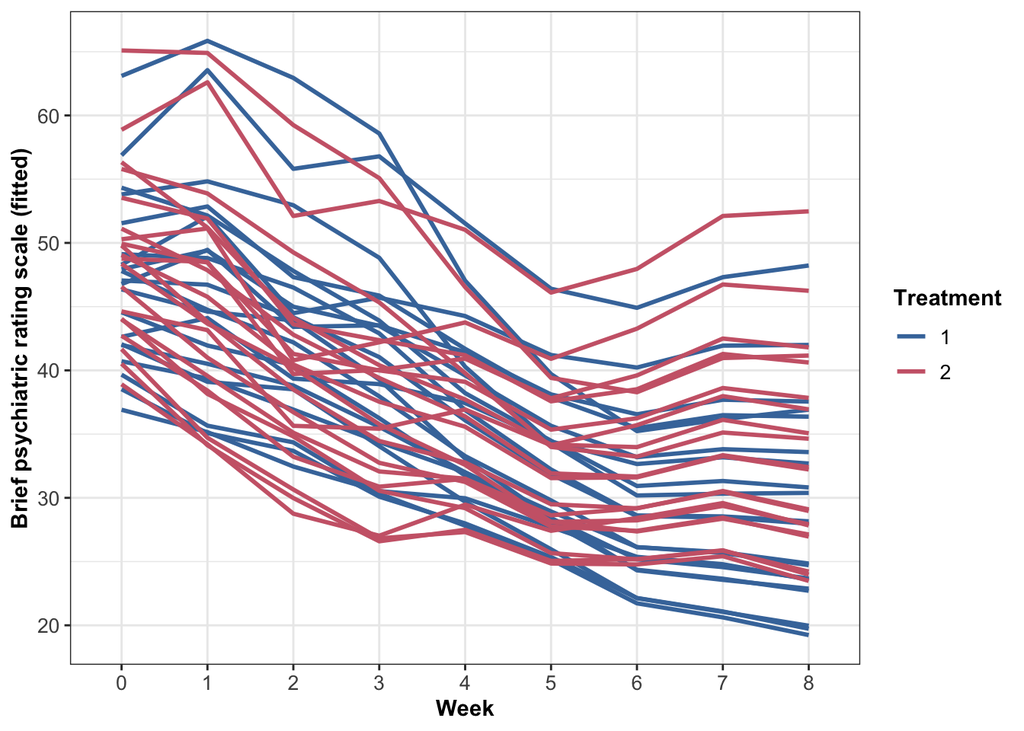

```r
# Create a vector of the fitted values.
Fitted <- fitted(bprs_ref2)

# Add fitted values to data frame.
new_bprs <- bprs %>% mutate(fitted = Fitted)

# Plot data.
ggplot(new_bprs,
       aes(
         x = week,
         y = fitted,
         group = interaction(subject, treatment),
         color = treatment
       )) +
  geom_line(linewidth = 1) +
  labs(x = "Week", y = "Brief psychiatric rating scale (fitted)", color = "Treatment") +
  scale_color_manual(values = ptol_pal()(length(unique(bprs$treatment)))) +
  theme_bw() +
  theme(
    axis.title = element_text(face = "bold"),
    legend.title = element_text(face = "bold"),
    legend.text = element_text(size = 10),
    axis.text = element_text(size = 10)
  )
```